# Sampling and Simulation

Steve Elston

09/22/2022

# Review

- Axioms of probability; for discrete distribution

$$0 \le P(A) \le 1$$
$$P(S) = \sum_{a_i \in A}P(a_i) = 1$$
$$P(A\ \cup B) = P(A) + P(B)\\ if\ A \perp
B$$

- Expectation

$$\mathrm{E}[\mathbf{X}] = \sum_{i=1}^n
x_i\ p(x_i)$$

# Review

- The Categorical distribution - Discrete multi-variate distribution
  - For outcome $i$ we **one hot encode** the results as:
    $$\mathbf{e_i} = (0, 0, \ldots, 1, \ldots,
    0)$$
  - For a single trial the probabilities of the $k$ possible outcomes are expressed:
    $$\Pi = (\pi_1, \pi_2, \ldots,
    \pi_k)$$
  - Probability mass function as:

$$f(x_i| \Pi) = \pi_i$$

- Multivariate Normal distribution, parameterized by **n-dimensional vector of locations**, $\vec{\mathbf{\mu}}$ and $n$ x $n$ dimensional **covariance matrix**
  $$f(\vec{\mathbf{x}}) =
  \frac{1}{{\sqrt{(2 \pi)^k |\mathbf{\Sigma}|}}}exp \big(\frac{1}{2}
  (\vec{\mathbf{x}} - \vec{\mathbf{\mu}})^T \mathbf{\Sigma}
  (\vec{\mathbf{x}} - \vec{\mathbf{\mu}})\big)$$

# Review

- Conditional probability
  - One random variable depends on another
  - But not commutable
    $$P(A|B) = P(A) \nLeftrightarrow P(B|A) =
    P(B)$$
- Mutually exclusivity
  $$\begin{align}
  P(A|B) &= P(B|A) = 0\\
  P(A \cup B) &= P(A) + P(B)
  \end{align}$$
- Independence
  $$P(A|B) = P(A)$$

# Review

- Bayes’ theorem
  $$P(A|B) =
  \frac{P(B|A)P(A)}{P(B)}$$
- Marginal distribution
- For continuous distributon
  $$p(\theta_1) = \int_{\theta_2, \ldots, \theta_n}
  p(\theta_1, \theta_2, \ldots, \theta_n)\ d\theta2, \ldots, d
  \theta_n$$
- For discrete distribution
  $$p(\theta_1) = \sum_{\theta_2, \ldots, \theta_n}
  p(\theta_1, \theta_2, \ldots, \theta_n)$$

# Introduction

Sampling is a fundamental process in the collection and analysis of data

- Sampling is important because we almost never have data on an entire population
- **Sampling must be randomized** to preclude biases
- As sample size increases, the standard error decreases by the **law of large numbers**
- Key points to keep in mind:
  - Understanding sampling is essential to ensure data is representative of the entire population
  - Inferences on the sample say something about the population
  - The sample must be randomly drawn from the population
- Sampling from distributions is the building block of simulation
- We will take up the topic of resampling later

# Sampling Example

| Use Case | Sample | Population |
| --- | --- | --- |
| A/B Testing | The users we show either web sites A or B | All possible users, past present and future |
| World Cup Soccer | 32 teams which qualify in one season | All national teams in past, present and future years |
| Average height of data science students | Students in a data science class | All students taking data science classes world wide |
| Tolerances of a manufactured part | Samples taken from production lines | All parts manufactured in the past, present and future |
| Numbers of a species in a habitat | Population counts from sampled habitats | All possible habitats in the past, present and future |

- In several cases it is not only impractical, but impossible to collect data from the entire population
- We nearly always work with samples, rather than the entire population.

# Importance of Random Sampling

All statistical methods rely on the use of **randomized unbiased samples**

- Failure to randomized samples violates many key assumptions of statistical models
- An understanding of proper use of sampling methods is essential to statistical inference
- Most commonly used machine learning algorithms assume that training data are **unbiased** and **independent and identically distributed (iid)**
  - These conditions are only met if training data sample is randomized
  - Otherwise, the training data will be biased and not represent the underlying process distribution

# Sampling Distributions

Sampling of a population is done from an unknown **population distribution**, $\mathcal{F}$

- Any statistic, $s$, we compute for the generating process is based on a sample, $\hat{\mathcal{F}}$
- The statistic is an approximation, of a **population parameter**
  - For example, the **population mean** is $\mu$
  - Whereas, the **sample estimate** is $\bar{x}$
- If we continue to take random samples from the population and compute estimates of a statistic, we generate a **sampling distribution**
  - Hypothetical concept of the sampling distribution is a foundation of **frequentist statistics**
  - Example, we could continue to sample the population and compute sample means, $[\bar{x}_1, \bar{x}_2, \ldots, \bar{x}_n]$
- **Frequentist statistics** built on the idea of randomly resampling the population distribution and recomputing a statistic
  - In the frequentest world, statistical inferences are performed on the sampling distribution
  - Sampling process must not bias the estimates of the statistic

# Sampling Distributions

Sampling of a population is done from an unknown **population distribution**, $\mathcal{F}$

- Any statistic, $s$, we compute for the generating process is an approximation for the population, $s(\hat{\mathcal{F}})$

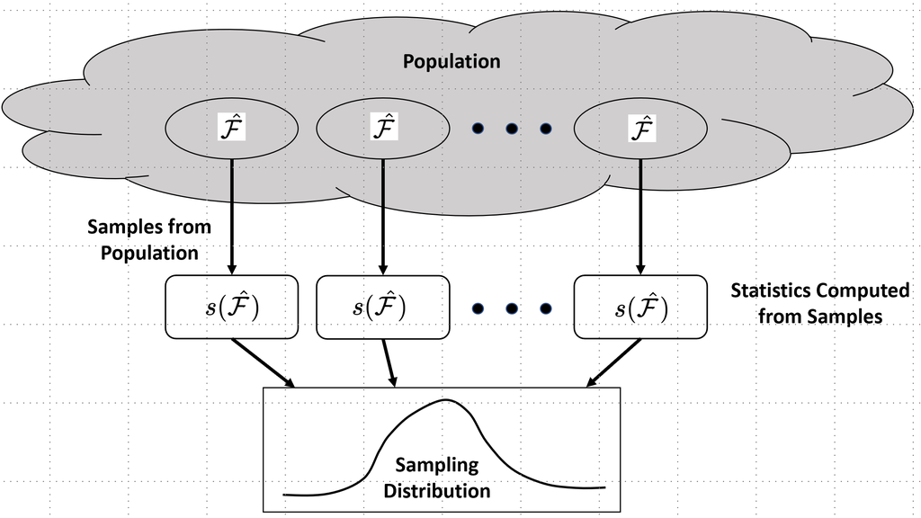

Sampling distribution of unknown population parameter

# Sampling and the Law of Large Numbers

The **weak law of large numbers** is a theorem that states that **statistics of independent unbiased random samples converge to the population values as more samples are used**

- Example, for a population distribution, $\mathcal{N}(\mu,\sigma)$, the sample mean is:

$$Let\ \bar{X} = \frac{1}{n}\sum_{i=1}^{n}
X_i$$

Then by the weak law of large numbers:

$$\bar{X} \rightarrow E(X) = \mu\\
as\\
n \rightarrow \infty$$

- This result is reassuring, the larger the sample the more the statistic converges to the population parameter

# Sampling and the Law of Large Numbers

The law of large numbers is foundational to statistics

- We rely on the law of large numbers whenever we work with samples
- Assume that **larger samples are more representatives of the population we are sampling**
- Is foundation of sampling theory, plus modern computational methods; simulation, bootstrap resampling, and Monte Carlo methods
- If the real world did not follow this theorem, then much of statistics (along with much of science and technology) would have to be rethought

# Sampling and the Law of Large Numbers

The weak law of large numbers has a long history

- Jacob Bernoulli posthumously published the first proof for the Binomial distribution in 1713
- Law of large numbers is sometimes referred to as **Bernoulli’s theorem**
- A more general proof was published by Poisson in 1837.

# Sampling and the Law of Large Numbers

A simple example

- The mean of fair coin flips (0,1) = (T,H) converges to the expected value with more flips
- The mean converges to the expected value of 0.5 for $n = 5, 50, 500, 5000$

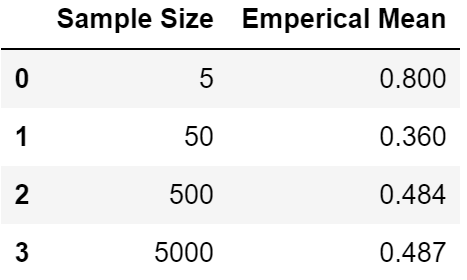

# Sampling and the Law of Large Numbers

A simple example; mean of fair coin flips (0,1) = (T,H) converges to the expected value with more flips

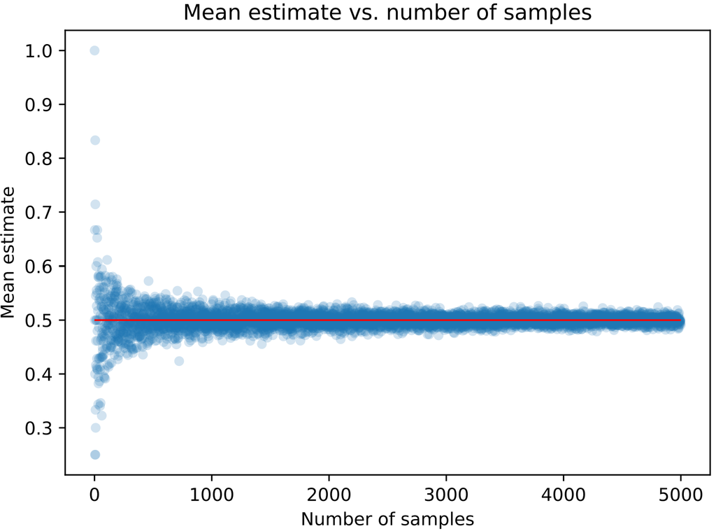

Convergance of mean estimates for fair coin

# the Central Limit Theorem (CLT)

- Law of large number is almost too obvious, but the CLT is tricky!
- Law of large number applied to any statistic, but the CLT applies only to the **mean**
- Let $X$ be a random variable representing the population
  - $X$ is allowed to have **any distribution** (not limited to normal), and let $\mu$ be your **true population mean** and $\sigma$ the **true population standard deviation**
  - Given sample size $n$ thee sampling distribution of $\bar X$is

$$\bar X \sim N(\mu, \frac{\sigma}{\sqrt
n})$$

# importance of CLT

CLT is a sort of guarantee

- Sampling distribution of mean estimates do not depend on the population the sample was drawn from
- **Standard deviation** $s$ of the sampling distribution of $\bar{x}$ converges as $1/\sqrt n$
- Only depends on the population’s mean and variance, and on the sample size
- CLT is the basis for hypothesis testing

# Example of CLT

Start with a mixture of Normal distributions

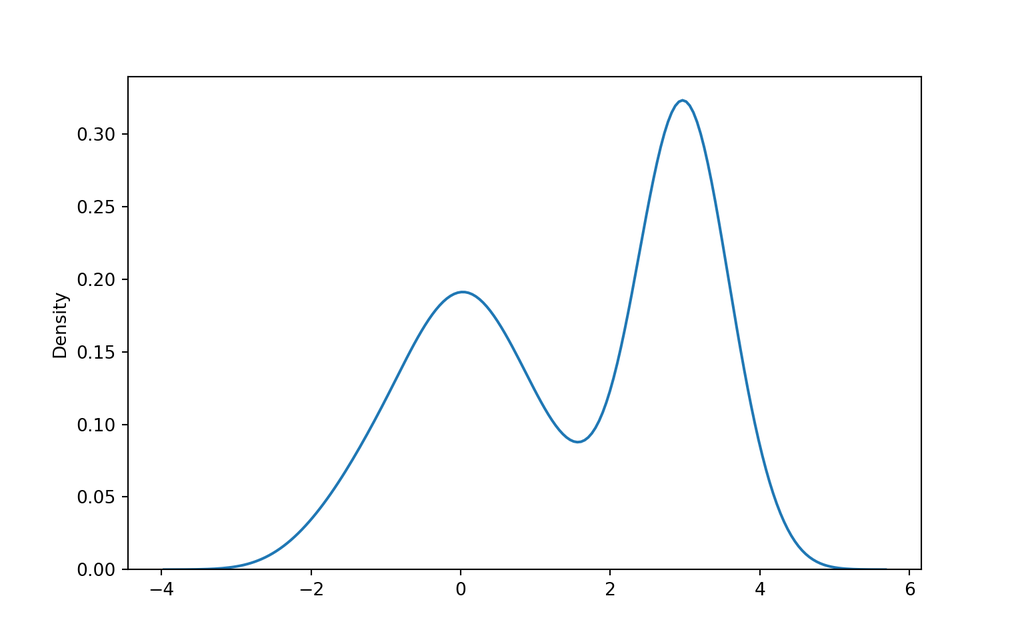

# Example CLT

Sample distribution of the mean of mixture of Normals is Normally distributed!

- Repetitively random sample the population, $size = 50$
- Compute the mean estimate, $\bar{x}$ for each sample

```python
x_means = np.array([
        nr.choice(x, size=50, replace=True).mean()
        for i in range(500)])

breaks = np.linspace(x_means.min(), x_means.max(), num=40)
fig, ax = plt.subplots(1,2, figsize=(12, 5) )
_ = ax[0].hist(x_means, bins=breaks)
_ = sm.qqplot(x_means, line='s', ax=ax[1])
```

# Example CLT

Sample distribution of the mean of mixture of Normals is Normally distributed!

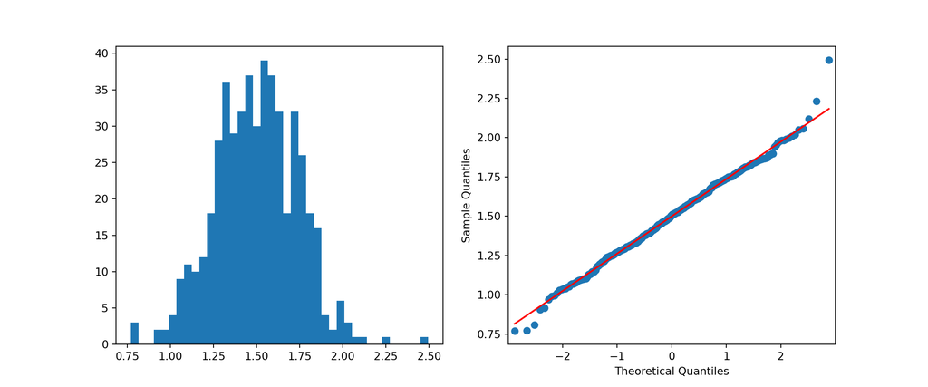

# Standard Error and Convergence for a Normal Distribution

As we sampled from a Normal distribution, the sample means converges to the population mean

- What can we say about the expected error of the mean estimate as the number of samples increases?
  - Population has standard deviation $\sigma$
  - This measure is known as the **standard error** of the sample mean
  - By the CLT the standard error is defined:

$$se = \pm
\frac{\sigma}{\sqrt{(n)}}$$

- Standard error decreases as the square root of $n$
- Example, if you wish to halve the error, you will need to sample four times as many values.

# Standard Error and Convergence for a Normal Distribution

As we sampled from a Normal distribution, the sample means converges to the population mean

- For the mean estimate, $\bar{x}$, define the uncertainty in terms of **confidence intervals**
- For 95% confidence interval:

$$CI_{95} =\bar{x} \pm 1.96\
se$$

# Convergence and Standard Errors for a Normal Distribution

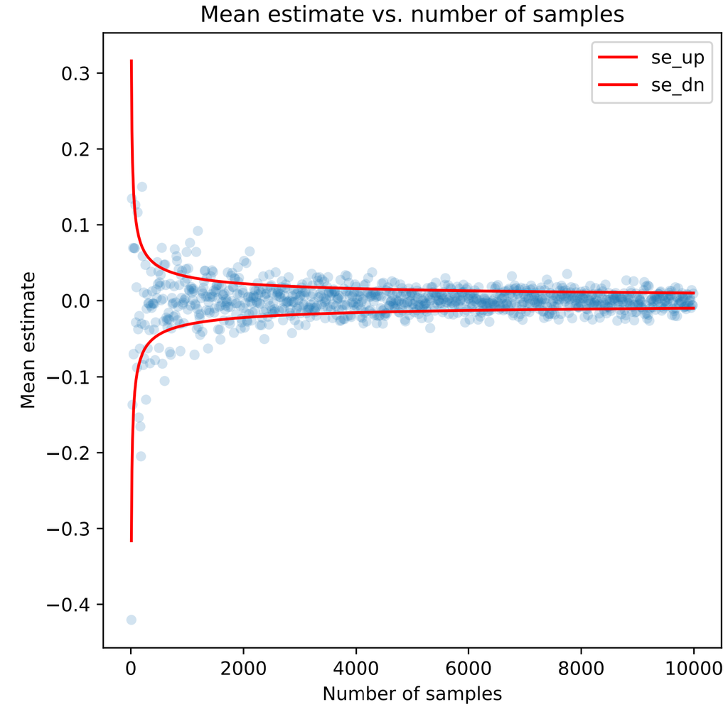

Convergance of mean estimates with standard errors

# Sampling Strategies

There are a great number of possible sampling methods.

- Some of the most commonly used methods
- **Bernoulli sampling**, a foundation of random sampling
- **Stratified sampling**, when groups with different characteristics must be sampled
- **Cluster sampling**, to reduce cost of sampling
- **Systematic sampling and convenience sampling**, a slippery slope

# Bernoulli Sampling

**Bernoulli sampling** is a widely used foundational random sampling strategy

- Bernoulli sampling has the following properties:
- A **single random sample** of the population is created
- A particular value in the population is sampled based on the outcome of a Bernoulli trial with fixed probability of success, $p$
- Example, a company sells a product by weight
  - To ensure the quality of a packaging process so few packages are underweight
  - Impractical to empty and weight the contents of every package
  - Random Bernoulli sample packages from the production line and weigh contents with say p=0.0001, or 1 out of 10,000
  - Statistical inferences are made from sample

# Bernoulli Sampling

An example with synthetic data. - Generate population of 10000 samples from the standard Normal distribution  
- The realizations are randomly divided into 4 groups with $p = [0.1,0.3,0.4,0.2]$  
- The probability of a sample being in a group is not uniform, and sums to 1.0.

```python
nr.seed(345)
population_size = 10000
data = pd.DataFrame({"var":nr.normal(size = population_size),
                     "group":nr.choice(range(4), size= population_size, p = [0.1,0.3,0.4,0.2])})
data.head(10)
```

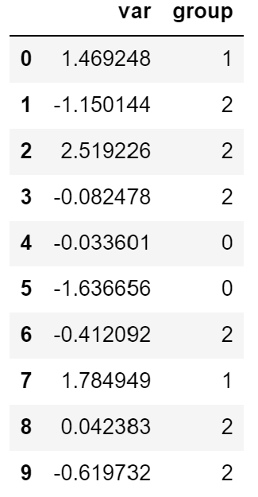

# Bernoulli Sampling

The population of 10000 samples from the standard Normal distribution

The mean of each group should be close to 0.0:  
1. The sample is divided between 4 groups  
2. Probability of sample from given group, $p=0.1$  
3. Summary statistics are computed for each group

```python
def count_mean(dat, p=1.0):
    import numpy as np
    import pandas as pd
    groups = dat.groupby('group') # Create the groups
    n_samples = np.int64(p * groups.size())
    se = np.sqrt(np.divide(groups.aggregate(np.var).loc[:, 'var'], n_samples))
    means = groups.aggregate(np.mean).loc[:, 'var']
    ## Create a data frame with the counts and the means of the groups
    out = pd.DataFrame({'Count': n_samples,
                        'Mean': means,
                        'SE': se,
                        'Upper_CI': np.add(means, 1.96 * se),
                        'Lower_CI': np.add(means, -1.96 * se)})
    print(out)
    return out
p = 0.1
count_mean(data, p)
```

# Bernoulli Sampling

The population of 10000 samples from the standard Normal distribution

The mean of each group should be close to 0.0:  
1. The sample is divided between 4 groups  
2. Probability of sample from given group, $p=0.1$  
3. Summary statistics are computed for each group

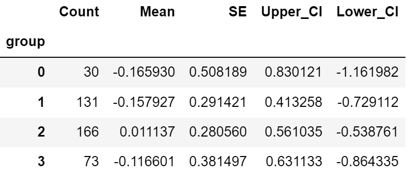

# Sampling Grouped Data

Group data is quite common in application

A few examples include:

1. Pooling opinion by county and income group, where income groups and counties have significant differences in population
2. Testing a drug which may have different effectiveness by sex and ethnic group
3. Spectral characteristics of stars by type

# Stratified Sampling

What is a sampling strategy for grouped or stratified data?

- **Stratified sampling** strategies are used when data are organized in **strata**
- **Simple Idea:** independently sample an equal numbers of cases from each strata
- The simplest version of stratified sampling creates an **equal-size Bernoulli sample** from each strata
- In many cases, nested samples are required
  - For example, a top level sample can be grouped by zip code, a geographic strata
  - Within each zip code, people are then sampled by income bracket strata
  - Equal sized Bernoulli samples are collected at the lowest level

# Example

Bernoulli sample 100 from each group and compute summary statistics

```python
def stratify(dat, p):
    groups = dat.groupby('group') # Create the groups
    nums = min(groups.size()) # Find the size of the smallest group
    num = int(p * dat.shape[0]) # Compute the desired number of samples per group
    if num <= nums:
        ## If sufficient group size, sample each group.
        ## We drop the unneeded index level and return,
        ## which leaves a data frame with just the original row index.
        return groups.apply(lambda x: x.sample(n=num)).droplevel('group')
    else: # Oops. p is to large and our groups cannot accommodate the choice of p.
        pmax = nums / dat.shape[0]
        print('The maximum value of p = ' + str(pmax))

p = 0.01
stratified = stratify(data, p)
count_mean(stratified)
```

# Example

Bernoulli sample 100 from each group and compute summary statistics

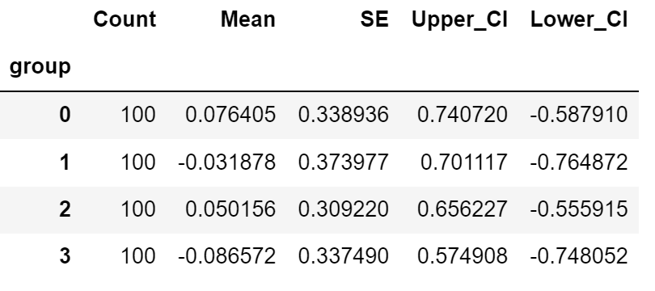

# Cluster Sampling

When sampling is expensive, a strategy is required to reduce the cost

- Examples of expensive to collect data:
  - Surveys of customers at a chain of stores
  - Door to door survey of homeowners
  - Sampling wildlife populations in a dispersed habitat

Population can be divided into randomly selected clusters:  
- Define the clusters for the population  
- Randomly select the required number of clusters  
- Sample from selected clusters  
- Optionally, stratify the sample within each cluster

# Cluster Sampling

As an example, select a few store locations and Bernoulli sample customers at these locations.

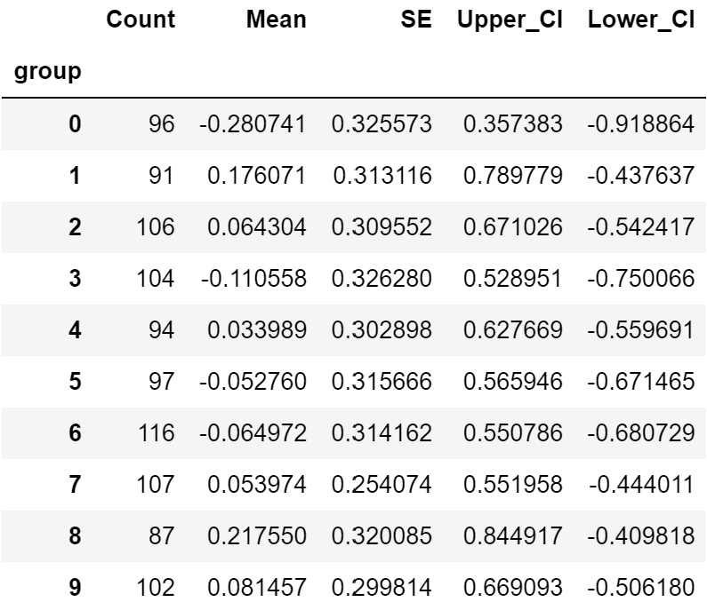

```python
## First compute the clusters
num_clusters = 10
num_vals = 1000
## Create a data frame with randomly sampled cluster numbers
clusters = pd.DataFrame({'group': range(num_clusters)}).sample(n = num_vals, replace = True)
## Add a column to the data frame with Normally distributed values
clusters.loc[:, 'var'] = nr.normal(size = num_vals)
count_mean(clusters)
```

# Cluster Sampling

Randomly select 3 clusters

```python
## Randomly sample the group numbers, making sure we sample from
## unique values of the group numbers.
clusters_samples = nr.choice(clusters.loc[:, 'group'].unique(),
                             size = 3, replace = False)
## Now sample all rows with the selected cluster numbers
clus_samples = clusters.loc[clusters.loc[:, 'group'].isin(clusters_samples), :]
```

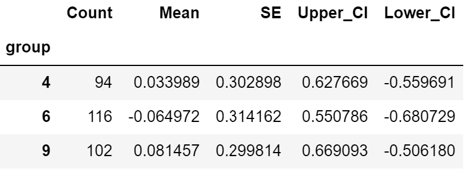

# Systematic Sampling

**Convenience and systematic sampling** are a slippery slope toward biased inferences

- Systematic sampling **lacks randomization**
- Convenience sampling selects the cases that are easiest to obtain
  - Commonly cited example known as **database sampling**
  - Example, the first N rows resulting from a database query
  - Example, every k-th case of the population

# A Few More Thoughts on Sampling

There are many practical aspects of sampling.

- Random sampling is essential to the underlying assumptions of statistical inference
- Whenever you are planning to sample data, make sure you have a clear sampling plan
- Know the number of clusters, strata, samples in advance
- Don’t just stop sampling when your desired result is achieved: e.g. error measure!

# Introduction to Simulation

Simulation enables data scientists to study the behavior of stochastic processes with complex probability distributions

- Most real-world processes have complex behavior, resulting in complex distributions of output values
  - Simulation is a practical approach to understanding these complex processes
- Two main purposes of simulation can be summarized as:
  - **Testing models:** If data simulated from the model do not resemble the original data, something is likely wrong
  - **Understand processes with complex probability distributions:** In these cases, simulation provides a powerful and flexible computational technique to understand behavior

# Introduction to Simulation

- As cheap computational power has become ubiquitous, simulation has become a widely used technique
- Simulations compute a large number of cases, or realizations
  - The computing cost of each realization must be low in any practical simulation
  - Realizations are drawn from complex probability distributions of the process model
- In many cases, realizations are computed using conditional probability distributions
  - The final or posterior distribution of the process is comprised of these realizations

# Representation as a Directed Acyclic Graphical Model

When creating a simulation with multiple conditionally dependent variables it is useful to draw a directed graph; a **directed acyclic graphical model or DAG**

- The graph is a communications device showing which variables are independent and which are conditionally dependent on others with the shapes used representing the type of nodes
- **Directed edges** show the dependency structure of the distributions
  - Arrows point to **child nodes** which are dependent on **parent nodes**
  - Child node is **conditional** on parent nodes

# Representation as a Directed Acyclic Graphical Model

When creating a simulation with multiple conditionally dependent variables it is useful to draw a directed graph; a **directed acyclic graphical model or DAG**

- **Probability distributions** of the variables are shown as **ellipses**
  - Distributions have parameters which must be estimated
- **Decision variables** are deterministic and are shown as **rectangles**
  - Decisions are determined by variables
  - Setting decision variables can be performed either manually or automatically
- **Utility nodes**, profit in this case, are shown as **diamonds**
  - Nodes represent a **utility function** given the dependencies in the graph
  - Utility calculations are deterministic given the input values

# Sandwich Shop Simulation

The sandwich shop simulation can be represented by a DAG

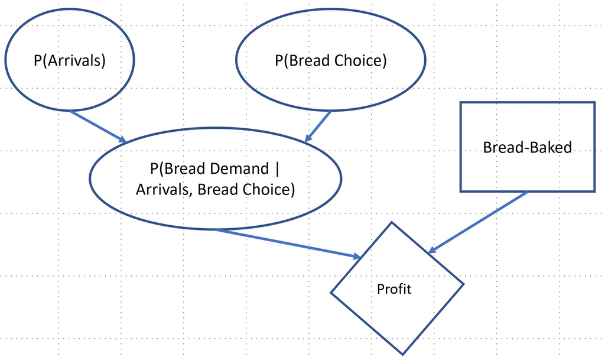

Directed graph of the distributions for profit simulation

# Sandwich Shop Simulation

Interpreting the DAG

- The DAG is a shorthand description of the simulation model
- Nodes with no dependency are independent distributions
  - Parameters must be known or estimated
  - Can be useful to vary the parameters
- **Child** distributions are conditional on their **parents**
  - Parameters must be known or estimated
  - Resulting distribution can be quite complex
- **Decision variables** deterministicly change the model parameters
- **Utility node** uses a fixed deterministic formula to compute the value for each realization of the simulaiton

# Tips on Building Simulations

Creating, testing and debugging simulation software can be tricky given the stochastic nature of simulation

- Build your simulation as a series of small, easily tested, chunks
- Test each small functional unit individually, including at least testing some typical cases, as well as boundary or extreme cases
- Test your overall simulation each time you add a new functional component - **avoid big bang integration!**
- Simulations are inherently stochastic, set a seed before you begin tests so they are repeatable

# Summary

Sampling is a fundamental process in the collection and analysis of data

- Sampling is important because we almost never have data on a whole population
- Sampling must be randomized to preclude biases
- As sample size increases the standard error of a statistic computed from the sample decreases by the law of large numbers
- Key points to keep in mind:
  - Understanding sampling is essential to ensure data is representative of the entire population
  - Use inferences on the sample to say something about the population
  - The sample must be randomly drawn from the population
- Sampling from distribution is the building block of simulation